# Creation of random points on network with CSR hypothesis

**Objectives:** notes on creation of *n* random points on a spatial network  
**Main reference**: Okabe (Atsuyuki) & Sugihara (Kokichi), *Spatial Analysis along Networks. Statistical and Computational Methods*, 2012, John Wiley & Sons, Ltd, UK, chapter 2

### Libraries and data

```r
library(tidyverse)
library(sf)
library(maptools)
library(sp)
library(spatstat.data)
library(spatstat.geom)
library(spatstat.core)
library(nlme)
library(spatstat.linnet)
library(ggspatial)
library(ggthemes)

reseau_jacoubet <- st_read(dsn = "data_Jacoubet/jacoubet_1825_1837_crs_2154.shp")
```

### Steps in creation of n random points on a network

We consider, as Okabe and Sugihara, *n* points generated on a network space *L* according to the homogeneous binomial point process. Then, the probability of a point being placed on arbitrary subnetwork *Ls* of *L* depends on the length of *Ls* and only length.

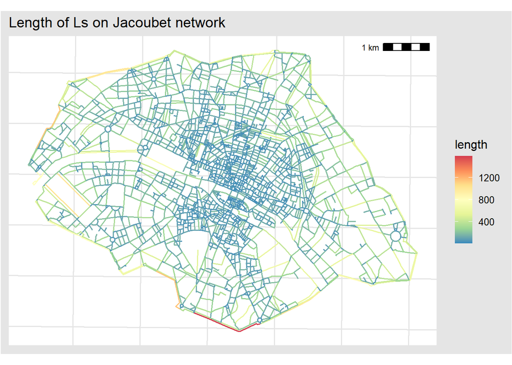

```r
# adding length on network
reseau_jacoubet <- reseau_jacoubet %>%
  mutate(length = as.numeric(round(x = st_length(x = .), digits = 2)))

# visu of length differences on network
ggplot() +
  geom_sf(data = reseau_jacoubet, aes(color = length), size = 0.7) +
  scale_color_distiller(palette = "Spectral") +
  ggspatial::annotation_scale(location = "tr",  width_hint = 0.2) +
  ggthemes::theme_igray() +
  theme(axis.text.x = element_blank(),
        axis.text.y = element_blank(),
        axis.ticks = element_blank(),
        axis.title.x = element_blank(),
        axis.title.y = element_blank()) +
  ggtitle("Length of Ls on Jacoubet network")
```

```r
# probability depending on length of Ls
proba <- as.numeric(reseau_jacoubet$length/sum(reseau_jacoubet$length))

# sampling depending on this probability
random_sample_csr <- sample(x = reseau_jacoubet$fid,
                            size = 100, # n = 100 points
                            replace = TRUE, prob = proba)

# table of the random sample
table_rss_csr <- reseau_jacoubet %>%
  left_join(enframe(random_sample_csr) %>%
              group_by(fid = value) %>%
              count() %>%
              ungroup(),
            by = "fid") %>%
  mutate(n = replace_na(data = n, replace = 0)) %>%
  filter(n > 0)

table_rss_csr %>%
  select(fid, length, n) %>%
  head()
```

|  | fid | length | n | geometry |
| --- | --- | --- | --- | --- |
| 1 | 41 | 53.77 | 1 |  |
| 2 | 70 | 166.12 | 1 |  |
| 3 | 117 | 35.46 | 1 |  |
| 4 | 121 | 181.40 | 1 |  |
| 5 | 165 | 104.57 | 1 |  |
| 6 | 171 | 114.08 | 1 |  |

```r
# spatial sampling depending on table of random sample
result_point_rss_csr <- st_sample(x = table_rss_csr, size = table_rss_csr$n) # an sfc object as multipoint

# transformation as sf object, geometry as points
result_point_rss_csr <- result_point_rss_csr %>%
  st_as_sf(.) %>%
  st_cast(x = ., to = "POINT")
```

#### Data visualization of random point pattern

With *n* = 100

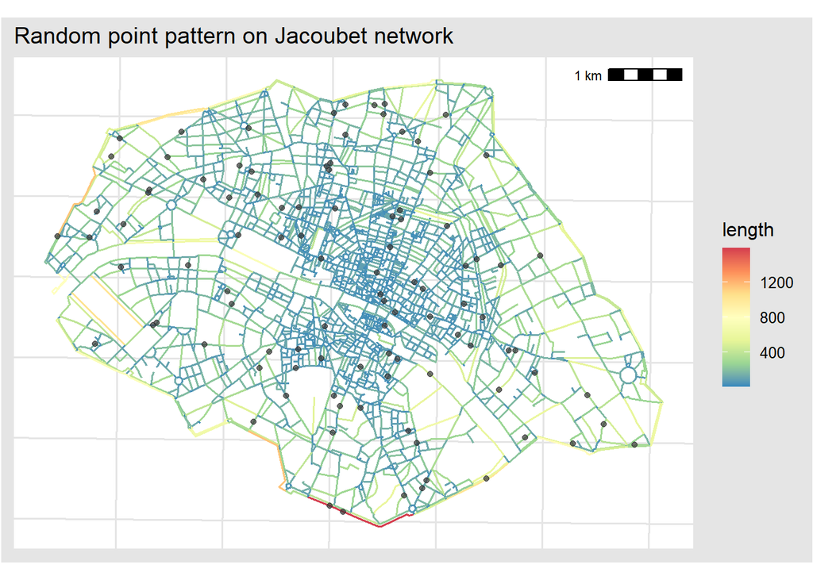

```r
# visu
ggplot() +
  geom_sf(data = reseau_jacoubet, aes(color = length), size = 0.7) +
  scale_color_distiller(palette = "Spectral") +
  geom_sf(data = result_point_rss_csr, color = "grey20", alpha = 0.7) +
  ggspatial::annotation_scale(location = "tr",  width_hint = 0.2) +
  ggthemes::theme_igray() +
  theme(axis.text.x = element_blank(),
        axis.text.y = element_blank(),
        axis.ticks = element_blank(),
        axis.title.x = element_blank(),
        axis.title.y = element_blank()) +
  ggtitle("Random point pattern on Jacoubet network")
```

### Fastest algorithms

The algorithms presented are quite slow as soon as the number of points to generate and the number of simulations are increased. It is much more relevant to use the functions of the package spatstat.linnet, designed to study points on a linear network.

```r
# creation of a linear network (object of class "linnet")
linnet_jacoubet <- maptools::as.linnet.SpatialLines(X =
                                                      as(reseau_jacoubet, "Spatial") # first: transform sf as SpatialLinesDataFrame
                                                    )

# creation of random spatial sampling with CSR hypothesis
liste_rss_csr <- runiflpp(n = 100, # number of points n
                          L = linnet_jacoubet,
                          nsim = 50) # 50 simulations of sampling

head(liste_rss_csr)
```

```
## List of spatial objects
##
## Simulation 1:
## Point pattern on linear network
## 100 points
## Linear network with 7135 vertices and 8631 lines
## Enclosing window: rectangle = [647640.1, 656138.1] x [6859014, 6865167] units
##
## Simulation 2:
## Point pattern on linear network
## 100 points
## Linear network with 7135 vertices and 8631 lines
## Enclosing window: rectangle = [647640.1, 656138.1] x [6859014, 6865167] units
##
## Simulation 3:
## Point pattern on linear network
## 100 points
## Linear network with 7135 vertices and 8631 lines
## Enclosing window: rectangle = [647640.1, 656138.1] x [6859014, 6865167] units
##
## Simulation 4:
## Point pattern on linear network
## 100 points
## Linear network with 7135 vertices and 8631 lines
## Enclosing window: rectangle = [647640.1, 656138.1] x [6859014, 6865167] units
##
## Simulation 5:
## Point pattern on linear network
## 100 points
## Linear network with 7135 vertices and 8631 lines
## Enclosing window: rectangle = [647640.1, 656138.1] x [6859014, 6865167] units
##
## Simulation 6:
## Point pattern on linear network
## 100 points
## Linear network with 7135 vertices and 8631 lines
## Enclosing window: rectangle = [647640.1, 656138.1] x [6859014, 6865167] units
```

We obtain lists of point pattern on linear network. Each list correspond to a simulation. We obviously can extract those simulations to obtain an object of class sf to visualize random point patterns.

```r
# first extraction
extract_list_rss_csr <- lapply(liste_rss_csr, `[[`, c("data")) # get table

# extract in loop: each table in one tibble
result_point_rss_csr_sim <- tibble(x = as.double(), y = as.double(), seg = as.numeric(), tp = as.double())

for (i in 1:length(extract_list_rss_csr)) {
  tableau <- as.data.frame(extract_list_rss_csr[[i]])
  colnames(x = tableau) <- c("x", "y", "seg", "tp")
  tableau <- tableau %>%
    as_tibble(.) %>%
    mutate(sim = i)

  result_point_rss_csr_sim <- result_point_rss_csr_sim %>%
    bind_rows(tableau)

}

result_point_rss_csr_sim_sf <- st_as_sf(x = result_point_rss_csr_sim, crs = 2154, coords = c("x", "y"))
head(result_point_rss_csr_sim_sf)
```

| seg | tp | sim | geometry |
| --- | --- | --- | --- |
| 3924 | 0.7976378 | 1 |  |
| 1286 | 0.2521823 | 1 |  |
| 4939 | 0.0276193 | 1 |  |
| 4565 | 0.9814851 | 1 |  |
| 5155 | 0.2299793 | 1 |  |
| 2495 | 0.4506837 | 1 |  |

#### Data visualization of 50 simulations of random point pattern

With *n* = 100 for each simulation

```r
# visu
ggplot() +
  geom_sf(data = reseau_jacoubet, color = "grey80", size = 0.7) +
  geom_sf(data = result_point_rss_csr_sim_sf, color = "red", alpha = 0.7) +
  ggspatial::annotation_scale(location = "tr",  width_hint = 0.2) +
  ggthemes::theme_igray() +
  theme(axis.text.x = element_blank(),
        axis.text.y = element_blank(),
        axis.ticks = element_blank(),
        axis.title.x = element_blank(),
        axis.title.y = element_blank()) +
  ggtitle("Random point patterns on Jacoubet network") +
  facet_wrap(~sim)
```

[figure not shown]